# 01-Data

Bill

09/12/2021

## Reading in the Data

In this section we read in all the data we require for our analysis. We start by reading in the connection log.

```r
df <- fread("http://www.secrepo.com/maccdc2012/conn.log.gz", nrows = 4000000)
```

We then add the column names, having found these in the Bro log variable names document. We then remove the empty columns and also note we can remove the UID given the tunnel data is absent.

```r
colnames(df) <- c("ts","uid","orig_ip","orig_port","resp_ip","resp_port",
                  "proto","service","duration","orig_bytes","resp_bytes",
                  "conn_state","local_orig", "missed_bytes","history",
                  "orig_pkts","orig_ip_bytes","resp_pkts","resp_ip_bytes",
                  "tunnel_parents")

df <- df[,-c("uid", "local_orig", "tunnel_parents")]
```

We set the minimum time-stamp to zero and round each to two decimal places, and then order the dataframe by time-stamp.

```r
df$ts <- round(df$ts - rep(min(df$ts), nrow(df)), digits=2)
df <- df[order(df$ts),]
df <- df
```

Lastly we replace any missing data values with NA, and check that everything has worked.

```r
df <- na_if(df, "-")
head(df)
```

```
##      ts        orig_ip orig_port         resp_ip resp_port proto service
## 1: 0.00 192.168.202.79     50463 192.168.229.251        80   tcp    <NA>
## 2: 0.00 192.168.202.79     46117 192.168.229.254       443   tcp    <NA>
## 3: 0.00 192.168.202.79     50465 192.168.229.251        80   tcp    http
## 4: 0.00 192.168.202.79     46119 192.168.229.254       443   tcp     ssl
## 5: 0.00 192.168.202.79     55173 192.168.229.153       445   tcp    <NA>
## 6: 0.01 192.168.202.79     50467 192.168.229.251        80   tcp    http
##     duration orig_bytes resp_bytes conn_state missed_bytes   history orig_pkts
## 1:      <NA>       <NA>       <NA>         SH            0        Fa         1
## 2:      <NA>       <NA>       <NA>         SF            0    dDafFr         3
## 3:  0.010000        166        214         SF            0   ShADfFa         4
## 4:  0.020000        544       1060         SF            0 ShADadfFr         8
## 5: 55.200000    6135377    1705080       RSTR            0    DdAaFr     43697
## 6:  0.010000        166        214         SF            0   ShADfFa         4
##    orig_ip_bytes resp_pkts resp_ip_bytes
## 1:            52         1            52
## 2:           382         9           994
## 3:           382         3           382
## 4:           968        13          1744
## 5:       8402145     43683       3975036
## 6:           382         3           382
```

Now we read in the Snort logs. Please download and unzip from https://www.secrepo.com/maccdc2012/maccdc2012_fast_alert.7z . Set your path for where you saved the logs, and change the prefix and suffix. My logs are called “FastSnort1.txt”, “FastSnort2.txt”, etc and thus my prefix is FastSnort and the suffix is “.txt”.

```r
path <- "/Users/willnunn/Desktop/Assessment/FastSnort"

prefix <- "FastSnort"
suffix <- ".txt"
```

Now we read in the Snort logs with the following piece of code:

```r
fast_slogs <- paste(path, "/", prefix, as.symbol(1), suffix, sep="") %>%
  fread(sep="\t",header=F)

for(i in c(2:5, 7:17)){
  l <- paste(path, "/", prefix, as.symbol(i), suffix, sep="") %>%
    fread(sep="\t", header=F)
  fast_slogs <- rbind(fast_slogs, l)
}
rm(i,l)
rm(suffix, prefix, path)
```

Unhelpfully, the time format in `fast_slogs` is different to the time-stamps in `df`. To aid with formatting the time I wrote the following function.

```r
convert_time <- function(string){
  day <- 86400 * (as.numeric(substr(string, 4, 5)) - 16)
  hour <- 3600 * (as.numeric(substr(string, 7, 8)) - 7)
  minute <- 60 * (as.numeric(substr(string, 10, 11))- 30)
  second <- as.numeric(substr(string, 13, 18))
  return(day + hour + minute + second)
}
```

We may now easily add derive the time-stamp for each entry in `fast_slogs`.

```r
colnames(fast_slogs) <- c("snort")
fast_slogs <- fast_slogs %>% mutate(ts = convert_time(substr(snort, 1, 21)))
fast_slogs <- fast_slogs[order(fast_slogs$ts),]
```

And, as before, we run a sanity check.

```r
head(fast_slogs)
```

```
##                                                                                                                                                                                                                               snort
## 1: 03/16-07:30:00.000000  [**] [1:2009358:5] ET SCAN Nmap Scripting Engine User-Agent Detected (Nmap Scripting Engine) [**] [Classification: Web Application Attack] [Priority: 1] {TCP} 192.168.202.79:50465 -> 192.168.229.251:80
## 2: 03/16-07:30:00.010000  [**] [1:2009358:5] ET SCAN Nmap Scripting Engine User-Agent Detected (Nmap Scripting Engine) [**] [Classification: Web Application Attack] [Priority: 1] {TCP} 192.168.202.79:50467 -> 192.168.229.251:80
## 3: 03/16-07:30:00.030000  [**] [1:2009358:5] ET SCAN Nmap Scripting Engine User-Agent Detected (Nmap Scripting Engine) [**] [Classification: Web Application Attack] [Priority: 1] {TCP} 192.168.202.79:50469 -> 192.168.229.251:80
## 4: 03/16-07:30:00.040000  [**] [1:2009358:5] ET SCAN Nmap Scripting Engine User-Agent Detected (Nmap Scripting Engine) [**] [Classification: Web Application Attack] [Priority: 1] {TCP} 192.168.202.79:50471 -> 192.168.229.251:80
## 5:                      03/16-07:30:00.050000  [**] [1:2102924:4] GPL NETBIOS SMB-DS repeated logon failure [**] [Classification: Unsuccessful User Privilege Gain] [Priority: 1] {TCP} 192.168.229.153:445 -> 192.168.202.79:55173
## 6:                             03/16-07:30:00.050000  [**] [1:2924:3] NETBIOS SMB-DS repeated logon failure [**] [Classification: Unsuccessful User Privilege Gain] [Priority: 1] {TCP} 192.168.229.153:445 -> 192.168.202.79:55173
##      ts
## 1: 0.00
## 2: 0.01
## 3: 0.03
## 4: 0.04
## 5: 0.05
## 6: 0.05
```

## Size Problem

The conn.log dataset is fairly large and both groups were severely impacted by the speed of their algorithms for attaching the Snort logs. The size of the connection log made it unfeasible to check whether every connection resulted in a Snort alert. After some serious deliberation Chentian and I decided to limit our investigation to the first **forty minutes (this may need to be changed)** of the connections. I’d checked the distribution of Snort alerts against time in my EDA and saw enough alerts within the first **forty minutes** to justify this decision.

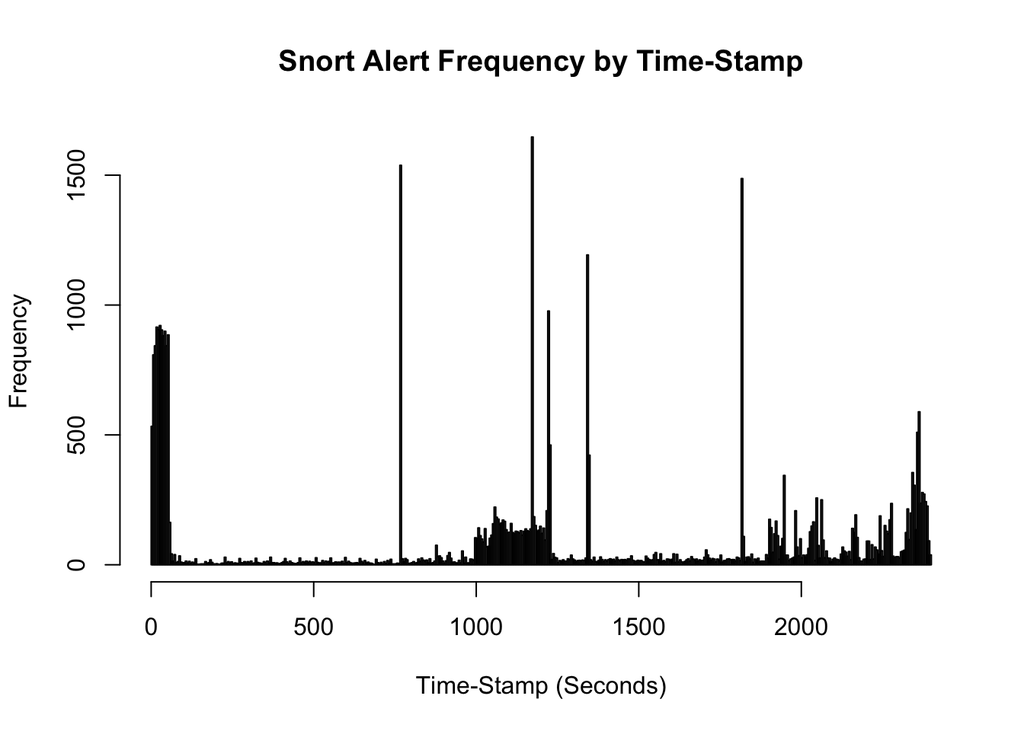

```r
hist(fast_slogs[which(fast_slogs$ts < 2400),]$ts, breaks = 500, main = "Snort Alert Frequency by Time-Stamp",
xlab = "Time-Stamp (Seconds)")
```

In the preceding section we imported the Snort logs for the full time interval, given we will now only consider the first **forty minutes** of connections we reduce our dataframes.

```r
df <- df[which(df$ts < 2400),]
slogs <- fast_slogs[which(fast_slogs$ts < 2400.1),]
rm(fast_slogs)
```

As has already been stated, the algorithm for attaching the Snort alerts was no Asafa Powell. We therefore just present the code of our algorithm below and read it’s pre-computed output from Google drive. Our algorithm requires that `df` has a `row_identifier` variable.

```r
row_identifier <- 1:nrow(df)
df <- cbind(df, row_identifier)
rm(row_identifier)
```

The algorithm I give below is the algorithm used to derive the list of rows which resulted in Snort alerts. I wrote similar algorithms for the same task which were much faster (linear in number of Snort alerts attached), but I wasn’t totally confident that these attached all the Snort logs correctly. I was more concerned by correctness than speed so opted for the safer bet.

```r
att <- c()

for(i in 1:nrow(slogs)){
  time_bound <- as.numeric(slogs[i,2])
  reduced_df <- df[which(between(df$ts, time_bound - 0.1, time_bound)),]
  for(j in 1:nrow(reduced_df)){
    if(grepl(as.character(reduced_df[j,2]), slogs[i,1])&
       grepl(as.character(reduced_df[j,3]), slogs[i,1])&
       grepl(as.character(reduced_df[j,4]), slogs[i,1])&
       grepl(as.character(reduced_df[j,5]), slogs[i,1])){
      att <- c(att, as.character(reduced_df[j,18]))
    }
  }
}

att <- sort(unique(att))
```

The search over `reduced_df`, which can be quite large when there’s lots of connections in the small time interval, is the subroutine which severely limits the speed of this algorithm. The other subroutine which could also be optimised is the derivation of `reduced_df` using the `which` procedure- one could make use of the time ordering and caching to quicken the derivation.

We now retrieve the pre-computed labels:

```r
att <- read.csv("/Users/willnunn/Desktop/Assessment/FirstForty.csv",
                row.names = 1)
```

We can now add our labels and prepare ourselves for classification.

```r
conn_type <- rep(0, nrow(df))
conn_type[att$x] = 1
df <- cbind(df, conn_type)
rm(conn_type, slogs, att)
```

Finally we check that the 3rd, 5th and 6th values of the `conn_type` column are all `1`.

```r
head(df$conn_type, 6)
```

```
## [1] 0 0 1 0 1 1
```

Excellent! We use this dataset for the rest of the project.